# Machine Learning 1

Assignment 1 - CEU 2018

Cagdas Yetkin, Business Analytics Part Time

2018-01-28

## Packages

```r
library(doParallel)
library(caret)
library(data.table)
library(purrr)
library(GGally)
library(dplyr)
library(descr)
library(imputeR)
library(tidyr)

registerDoParallel(cores = 4)
theme_set(theme_bw())
```

# Model selection with a validation set

Take the real estate dataset used in class and make log_price your target variable

```r
data <- fread("kc_house_data.csv")
data[, `:=`(floors = as.numeric(floors), zipcode = factor(zipcode))]
data[, log_price := log(price)]
data[, c("id", "date", "sqft_living15", "sqft_lot15", "price") := NULL]
set.seed(1234)
```

cut your data into three parts: 50% should be your training data, 25% each your validation and test sets (cut data into two parts, then further cut one part into two)

```r
my_ratio <- 0.5
train_indices <- createDataPartition(y = data[["log_price"]],
                                     times = 1,
                                     p = my_ratio,
                                     list = FALSE)
data_train     <- data[train_indices, ]
data_remaining <- data[-train_indices, ]
val_test_indices <- createDataPartition(y = data_remaining[["log_price"]],
                                     times = 1,
                                     p = my_ratio,
                                     list = FALSE)
data_validation <- data_remaining[val_test_indices, ]
data_test       <- data_remaining[-val_test_indices, ]
```

Train three models on the training data via caret, without cross validation (method = “none”):

a linear model lm with only using sqft_living as a predictor (a simple benchmark)

a linear model lm using all available features

a regression tree (rpart) with cp = 0.0001 (the tune grid should be a dataframe with one column cp and one row with value 0.0001)

For lm models, the tuneGrid argument should not be specified.

```r
train_control <- trainControl(method = "none")
simple_linear_fit <- train(log_price ~ sqft_living,
                  data = data_train,
                  method = "lm",
                  trControl = train_control)
linear_fit <- train(log_price ~ .,
                  data = data_train,
                  method = "lm",
                  trControl = train_control)
tune_grid <- data.frame("cp" = c(0.0001))
rpart_fit <- train(log_price ~ .,
                   data = data_train,
                   method = "rpart",
                   trControl = train_control,
                   tuneGrid = tune_grid)
```

Compare your models on the validation set and choose the one with the best performance (using RMSE). Use predict.train for prediction just like we used predict in class.

```r
RMSE <- function(x, true_x) sqrt(mean((x - true_x)^2))
simple_linear_rmse <- RMSE(predict.train(simple_linear_fit, newdata = data_validation, type = 'raw'), data_validation$log_price)
simple_linear_rmse
```

```
[1] 0.3797396
```

```r
linear_rmse <- RMSE(predict.train(linear_fit, newdata = data_validation, type = 'raw'), data_validation$log_price)
```

```
prediction from a rank-deficient fit may be misleading
```

```r
linear_rmse
```

```
[1] 0.190462
```

```r
rpart_rmse <- RMSE(predict.train(rpart_fit, newdata = data_validation, type = 'raw'), data_validation$log_price)
rpart_rmse
```

```
[1] 0.2192006
```

Evaluate the final model on the test set. Why is it important to have this final set of observations set aside for evaluation? (Hint: think about what we used the validation set for.)

```r
final_performance_measure <- RMSE(predict.train(linear_fit, newdata = data_test, type = 'raw'), data_test$log_price)
```

```
prediction from a rank-deficient fit may be misleading
```

```r
final_performance_measure
```

```
[1] 0.1885708
```

We create partitions for different purposes. We first fit out models on training set. We choose the best performer based on validation set results. Finally we test the winner on observations which our model have never seen before to estimate how it can generalize.

This is like a swimming competition. There was a winner. But we want to see her performance in a different pool condition she has never seen before (or without her husband watching her)

# Predicting developer salaries

```r
data <- fread("survey_results_public_selected.csv")
data <- data[!is.na(Salary) & Salary > 0]
data <- data[complete.cases(data)]
data <- data[, Gender := ifelse(Gender == "Male", "Male",
                              ifelse(Gender == "Female", "Female", "Other"))]
large_countries <- data[, .N, by = "Country"][N > 60][["Country"]]
data <- data[, Country := ifelse(Country %in% large_countries, Country, "Other")]
```

1. Describe what the data cleansing steps mean: 1) Keep the observations where the Salary is not NA and greater than zero. 2) Apply complete_cases on top of it to have only the cases without missing values. However, we will need to fix the missing values in Gender column separetely. They are empty strings. 3) Update the gender column to write ‘Other’ for the observations where they are not Male or Female. 4) Create a vector for the large countries which have more than 60 observations in data 5) Update the country column in data by using this vector to have country name if it is a large country, call it ‘Other’ if not.
2. Using graphs, find at least two interesting features that can contribute to understanding developer salaries

Look at the outcome variable, Salary first…

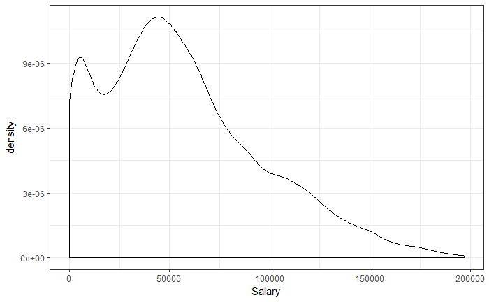

```r
ggplot(data, aes(Salary)) + geom_density()
```

We might want to see the log Salary since we see a right skewed output. Bimodal shape is also creeping into my brain. I will try to discover what is causing this bimodal shape…

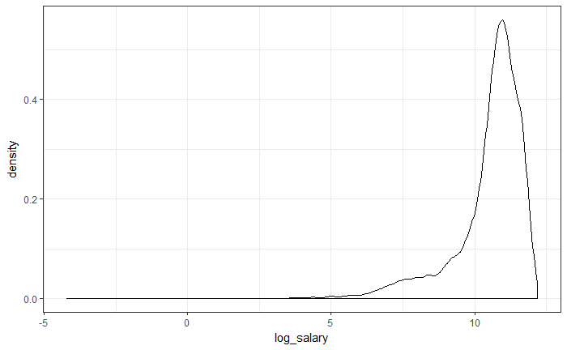

```r
data[, log_salary := log(Salary)]
ggplot(data, aes(log_salary)) + geom_density()
```

In fact we don’t see a nice log-normal but it will not stop us from trying out some models with log Salaries.

What are my variables?

```r
names(data)
```

```
[1] "Salary"          "TabsSpaces"      "YearsProgram"    "Country"
[5] "Gender"          "FormalEducation" "ProgramHobby"    "CompanySize"
[9] "log_salary"
```

```r
data[, .N, by = TabsSpaces][order(N, decreasing = T)]
```

| TabsSpaces | N |
| --- | --- |
| Spaces | 5511 |
| Tabs | 5033 |
| Both | 1877 |
|  | 464 |

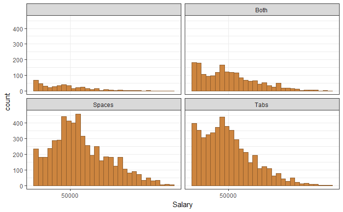

```r
ggplot(data, aes(Salary)) +
    geom_histogram(fill = "tan3", color= "tan4") +
    facet_wrap(~TabsSpaces) + scale_x_continuous(breaks = 50000)
```

Spacing and Tabbing are referring to different programming languages. These are essentially the differences between low and high level languages. Such as Python (Tab) and C++ (Space). We can see that high level languages such as Python have negative impact on average salaries in our data.

```r
data[, .N, by = YearsProgram][order(N, decreasing = T)]
```

| YearsProgram | N |
| --- | --- |
| 20 or more years | 2578 |
| 9 to 10 years | 964 |
| 5 to 6 years | 792 |
| 4 to 5 years | 789 |
| 10 to 11 years | 727 |
| 6 to 7 years | 718 |
| 7 to 8 years | 692 |
| 14 to 15 years | 652 |
| 3 to 4 years | 609 |
| 15 to 16 years | 572 |

[output cut: 12 more lines]

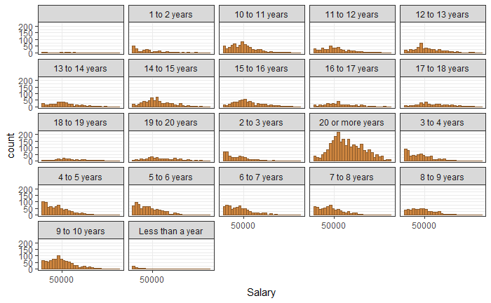

```r
ggplot(data, aes(Salary)) +
    geom_histogram(fill = "tan3", color= "tan4") +
    facet_wrap(~YearsProgram) + scale_x_continuous(breaks = 50000)
```

Here we can see the effect of being an experienced developer! The inexperienced and/or less experienced developers are pulling the salaries to the left significantly.

```r
data[, .N, by = Country][order(N, decreasing = T)]
```

| Country | N |
| --- | --- |
| United States | 3781 |
| United Kingdom | 1386 |
| Germany | 994 |
| Other | 990 |
| India | 819 |
| Canada | 667 |
| France | 477 |
| Poland | 317 |
| Spain | 278 |
| Australia | 255 |

[output cut: 25 more lines]

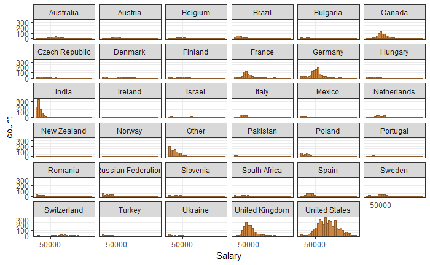

```r
#data[, salary_avg := mean(Salary), by = Country]
ggplot(data, aes(Salary)) +
    geom_histogram(fill = "tan3", color= "tan4") +
    facet_wrap(~Country) + scale_x_continuous(breaks = 50000)
```

A quick look reveals that Salaries in India and Others (small countries) have effect on that bimodal shape in the Salary density plot we have seen at the beginning. Country really matters!

```r
data[, .N, by = Gender][order(N, decreasing = T)]
```

| Gender | N |
| --- | --- |
| Male | 10664 |
| Other | 1403 |
| Female | 818 |

Gender gap is huge study on its own in IT business. I will not enter into this one at this time.

I want to look at a few more tablular frequencies without calling ggplot.

```r
data[, .N, by = FormalEducation][order(N, decreasing = T)]
```

| FormalEducation | N |
| --- | --- |
| Bachelor's degree | 6403 |
| Master's degree | 3077 |
| Some college/university study without earning a bachelor's degree | 2049 |
| Secondary school | 760 |
| Doctoral degree | 293 |
| Professional degree | 143 |
| I never completed any formal education | 60 |
| Primary/elementary school | 55 |
| I prefer not to answer | 45 |

```r
data[, .N, by = ProgramHobby][order(N, decreasing = T)]
```

| ProgramHobby | N |
| --- | --- |
| Yes, I program as a hobby | 6130 |
| Yes, both | 3621 |
| No | 2440 |
| Yes, I contribute to open source projects | 694 |

```r
data[, .N, by = CompanySize][order(N, decreasing = T)]
```

| CompanySize | N |
| --- | --- |
| 20 to 99 employees | 3065 |
| 100 to 499 employees | 2609 |
| 10,000 or more employees | 1823 |
| 10 to 19 employees | 1335 |
| 1,000 to 4,999 employees | 1288 |
| Fewer than 10 employees | 1182 |
| 500 to 999 employees | 851 |
| 5,000 to 9,999 employees | 519 |
| I don't know | 161 |
| I prefer not to answer | 41 |

[output cut: 1 more lines]

I have 11 observations missing for Company Size and YearsProgram.

I have also 464 missing for TabsSpaces. Are they missing at random is the question. It looks like they are similar to the distributions of the entire data.

The people who didn’t give TabsSpace information also didn’t give their Gender information (check the table called NoInfoTabSpaces below). Looks like these people don’t want to share much info about themselves.

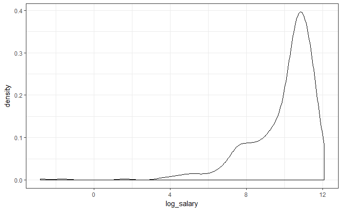

```r
NoInfoTabSpaces <- data[TabsSpaces == '']
ggplot(NoInfoTabSpaces, aes(log_salary)) + geom_density()
```

```r
NoInfoTabSpaces[, .N, by = Country][order(N, decreasing = T)]
```

| Country | N |
| --- | --- |
| United States | 106 |
| India | 74 |
| United Kingdom | 52 |
| Other | 39 |
| Germany | 25 |
| Spain | 18 |
| Canada | 18 |
| France | 15 |
| Brazil | 11 |
| Russian Federation | 11 |

[output cut: 24 more lines]

```r
NoInfoTabSpaces[, .N, by = Gender]
```

| Gender | N |
| --- | --- |
| Other | 434 |
| Male | 28 |
| Female | 2 |

```r
NoInfoTabSpaces[, .N, by = YearsProgram][order(N, decreasing = T)]
```

| YearsProgram | N |
| --- | --- |
| 20 or more years | 57 |
| 5 to 6 years | 42 |
| 4 to 5 years | 37 |
| 3 to 4 years | 35 |
| 6 to 7 years | 35 |
| 9 to 10 years | 30 |
| 2 to 3 years | 25 |
| 14 to 15 years | 25 |
| 1 to 2 years | 23 |
| 7 to 8 years | 21 |

[output cut: 12 more lines]

3. Create a training and a test set assigning 70% to the training set and 30% as the test set.

```r
set.seed(123)
my_ratio <- 0.7
train_indices <- createDataPartition(y = data[["log_salary"]],
                                     times = 1,
                                     p = my_ratio,
                                     list = FALSE)
data_train <- data[train_indices, ]
data_test  <- data[-train_indices, ]
```

4. Using caret train at least two predictive models to predict the logarithm of Salary (they can be of the same family but with different hyperparameters or they can be of different families like we used lm and rpart in the first exercise). Make sure NOT to include Salary as a predictor variable. Also, just before calling train, remember to use set.seed

```r
set.seed(123)
train_control <- trainControl(method = "cv", number = 10)
glm_tune_grid <- expand.grid("alpha" = 1,
                             "lambda" = c(0.1, 0.01, 0.001, 0.0001))
lasso_fit <- train(log_salary ~ . -Salary,
                   data = data_train,
                   method = "glmnet",
                   preProcess = c("center", "scale"),
                   tuneGrid = glm_tune_grid,
                   trControl = train_control)
rpart_tune_grid <- data.frame("cp" = c(0.01, 0.001, 0.0001, 0.00001))
rpart_fit <- train(log_salary ~ . -Salary,
                   data = data_train,
                   method = "rpart",
                   preProcess=c("center", "scale"),
                   trControl = train_control,
                   tuneGrid = rpart_tune_grid)
lasso_fit
```

```
glmnet

9020 samples
   8 predictor

Pre-processing: centered (81), scaled (81)
Resampling: Cross-Validated (10 fold)
Summary of sample sizes: 8119, 8118, 8118, 8118, 8118, 8117, ...
Resampling results across tuning parameters:

  lambda  RMSE       Rsquared   MAE
  1e-04   0.9599273  0.4973652  0.5365672
  1e-03   0.9599939  0.4972632  0.5361528
  1e-02   0.9630852  0.4945720  0.5353857
  1e-01   1.0780583  0.3885300  0.6363132

Tuning parameter 'alpha' was held constant at a value of 1
RMSE was used to select the optimal model using the smallest value.
The final values used for the model were alpha = 1 and lambda = 1e-04.
```

```r
rpart_fit
```

```
CART

9020 samples
   8 predictor

Pre-processing: centered (81), scaled (81)
Resampling: Cross-Validated (10 fold)
Summary of sample sizes: 8118, 8118, 8117, 8118, 8118, 8118, ...
Resampling results across tuning parameters:

  cp     RMSE      Rsquared   MAE
  1e-05  1.038016  0.4234991  0.5928272
  1e-04  1.033831  0.4267465  0.5864292
  1e-03  1.003770  0.4519031  0.5750640
  1e-02  1.076980  0.3663168  0.6432877

RMSE was used to select the optimal model using the smallest value.
The final value used for the model was cp = 0.001.
```

### Model selection via cross validation

```r
resamps <- resamples(list("regression tree" = rpart_fit,
                          "lasso" = lasso_fit))
summary(resamps)
```

```
Call:
summary.resamples(object = resamps)

Models: regression tree, lasso
Number of resamples: 10

MAE
                     Min.   1st Qu.    Median      Mean   3rd Qu.      Max. NA's
regression tree 0.5425677 0.5614325 0.5745128 0.5750640 0.5899957 0.6077250    0
lasso           0.4880023 0.5217082 0.5379636 0.5365672 0.5504624 0.5735996    0

RMSE
                     Min.   1st Qu.    Median      Mean  3rd Qu.     Max. NA's
regression tree 0.8930779 0.9563841 1.0067810 1.0037705 1.064131 1.095585    0
lasso           0.8147511 0.8706572 0.9966843 0.9599273 1.029428 1.104267    0

Rsquared
                     Min.   1st Qu.    Median      Mean   3rd Qu.      Max. NA's
regression tree 0.3864801 0.4360132 0.4580494 0.4519031 0.4753730 0.5131330    0
lasso           0.4312333 0.4527912 0.4941196 0.4973652 0.5458076 0.5651749    0
```

Glmnet Model RMSE is a bit better than Tree based on their RMSE and Rsquared results. I picked an alpha value of 1, which means LASSO and it is the winner.

evaluate its performance on the test set

```r
postResample(data_test$log_salary, predict(lasso_fit, data_test))
```

```
     RMSE  Rsquared       MAE
0.9488225 0.4898985 0.5369613
```

```r
test_prediction <- predict.train(lasso_fit, newdata = data_test)
RMSE(test_prediction, data_test[["log_salary"]])
```

```
[1] 0.9488225
```

Compare the true and predicted values of the test set on a graph. How do you evaluate the model fit based on this graph?

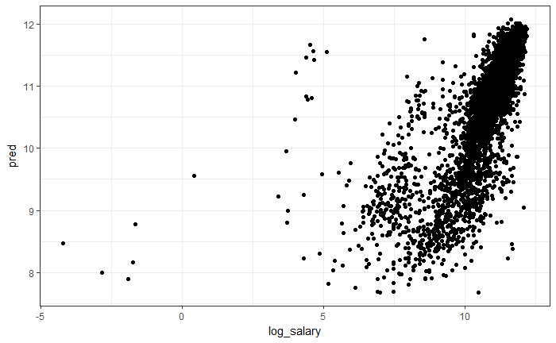

```r
data_test[, pred := test_prediction]
ggplot(data_test, aes(log_salary, pred)) + geom_point()
```

Looks like we are making big mistakes

```r
data_test[, pred_level := exp(test_prediction)*exp(var(test_prediction)/2)]
```

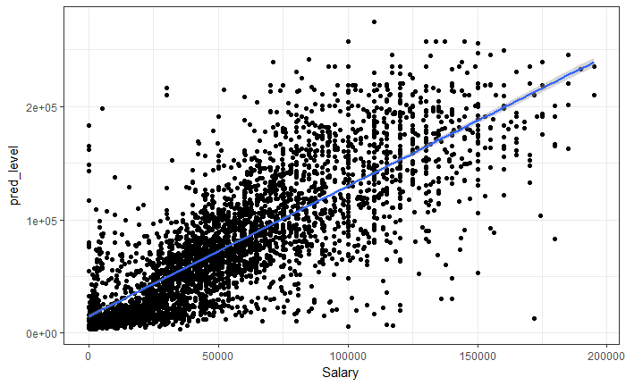

```r
ggplot(data_test, aes(Salary, pred_level)) + geom_point() + geom_smooth(method = 'lm', se = T)
```

Bad news for homoskedasticity!

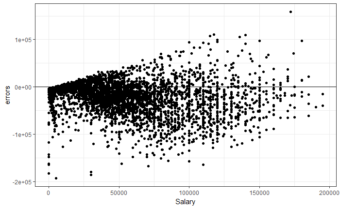

Errors would cluster around zero randomly if we had a nice model. We are performing a bit better for the low salary groups. However as the real Salary increaes, we are doing more and more mistakes.

We should go back and rethink our strategy. It would be interesting to check how some other models are performing. Especially a random forest with preProcessing for factors to use knnImpute or some more data cleaning and preparation. Because I want to capture the differences based on factors like countries better.

# Leave-one-out cross validation

1. This can be a very expensive computation for large dataset and this is a disadvantage
2. We are maximizing our validation. This is the maximum number of validations we can do with the data on hand.

   In k-fold cross validation the prediction error, is defined as the average of the prediction errors obtained on each fold. And there is an overlap in training sets. This overlap is largest on LOOCV (learned models are a bit correlated). This reflects to variance and variance increases. Bias is lower in return with the expense of higher variance.

```r
library(titanic)
library(data.table)
library(dplyr)
library(caret)
data_train <- data.table(titanic_train)
# recode Survived to factor - needed for binary prediction
data_train[, Survived := factor(ifelse(Survived == 1, "survived", "died"))]
data_train[, Sex := factor(Sex)] #Convert sex to factor
sapply(data_train, function(x) {sum(is.na(x))}) #check for NAs
```

```
PassengerId    Survived      Pclass        Name         Sex         Age       SibSp
          0           0           0           0           0         177           0
      Parch      Ticket        Fare       Cabin    Embarked
          0           0           0           0           0
```

```r
#do some simple imputation for Age
data_train[, Age := ifelse(is.na(Age), median(Age, na.rm = T), Age), by = Fare]
data_train[, Age := ifelse(is.na(Age), median(Age, na.rm = T), Age)]
#have a look at your data
str(data_train)
```

```
Classes ‘data.table’ and 'data.frame':  891 obs. of  12 variables:
 $ PassengerId: int  1 2 3 4 5 6 7 8 9 10 ...
 $ Survived   : Factor w/ 2 levels "died","survived": 1 2 2 2 1 1 1 1 2 2 ...
 $ Pclass     : int  3 1 3 1 3 3 1 3 3 2 ...
 $ Name       : chr  "Braund, Mr. Owen Harris" "Cumings, Mrs. John Bradley (Florence Briggs Thayer)" "Heikkinen, Miss. Laina" "Futrelle, Mrs. Jacques Heath (Lily May Peel)" ...
 $ Sex        : Factor w/ 2 levels "female","male": 2 1 1 1 2 2 2 2 1 1 ...
 $ Age        : num  22 38 26 35 35 29 54 2 27 14 ...
 $ SibSp      : int  1 1 0 1 0 0 0 3 0 1 ...
 $ Parch      : int  0 0 0 0 0 0 0 1 2 0 ...
 $ Ticket     : chr  "A/5 21171" "PC 17599" "STON/O2. 3101282" "113803" ...
 $ Fare       : num  7.25 71.28 7.92 53.1 8.05 ...
 $ Cabin      : chr  "" "C85" "" "C123" ...
 $ Embarked   : chr  "S" "C" "S" "S" ...
 - attr(*, ".internal.selfref")=<externalptr>
```

```r
summary(data_train)
```

```
  PassengerId        Survived       Pclass          Name               Sex
 Min.   :  1.0   died    :549   Min.   :1.000   Length:891         female:314
 1st Qu.:223.5   survived:342   1st Qu.:2.000   Class :character   male  :577
 Median :446.0                  Median :3.000   Mode  :character
 Mean   :446.0                  Mean   :2.309
 3rd Qu.:668.5                  3rd Qu.:3.000
 Max.   :891.0                  Max.   :3.000
      Age            SibSp           Parch           Ticket               Fare
 Min.   : 0.42   Min.   :0.000   Min.   :0.0000   Length:891         Min.   :  0.00
 1st Qu.:22.00   1st Qu.:0.000   1st Qu.:0.0000   Class :character   1st Qu.:  7.91
 Median :29.00   Median :0.000   Median :0.0000   Mode  :character   Median : 14.45
 Mean   :29.84   Mean   :0.523   Mean   :0.3816                      Mean   : 32.20
 3rd Qu.:36.00   3rd Qu.:1.000   3rd Qu.:0.0000                      3rd Qu.: 31.00
 Max.   :80.00   Max.   :8.000   Max.   :6.0000                      Max.   :512.33
    Cabin             Embarked
 Length:891         Length:891
 Class :character   Class :character
 Mode  :character   Mode  :character
```

```r
glimpse(data_train)
```

```
Observations: 891
Variables: 12
$ PassengerId <int> 1, 2, 3, 4, 5, 6, 7, 8, 9, 10, 11, 12, 13, 14, 15, 16, 17, 18, 19, ...
$ Survived    <fctr> died, survived, survived, survived, died, died, died, died, surviv...
$ Pclass      <int> 3, 1, 3, 1, 3, 3, 1, 3, 3, 2, 3, 1, 3, 3, 3, 2, 3, 2, 3, 3, 2, 2, 3...
$ Name        <chr> "Braund, Mr. Owen Harris", "Cumings, Mrs. John Bradley (Florence Br...
$ Sex         <fctr> male, female, female, female, male, male, male, male, female, fema...
$ Age         <dbl> 22.0, 38.0, 26.0, 35.0, 35.0, 29.0, 54.0, 2.0, 27.0, 14.0, 4.0, 58....
$ SibSp       <int> 1, 1, 0, 1, 0, 0, 0, 3, 0, 1, 1, 0, 0, 1, 0, 0, 4, 0, 1, 0, 0, 0, 0...
$ Parch       <int> 0, 0, 0, 0, 0, 0, 0, 1, 2, 0, 1, 0, 0, 5, 0, 0, 1, 0, 0, 0, 0, 0, 0...
$ Ticket      <chr> "A/5 21171", "PC 17599", "STON/O2. 3101282", "113803", "373450", "3...
$ Fare        <dbl> 7.2500, 71.2833, 7.9250, 53.1000, 8.0500, 8.4583, 51.8625, 21.0750,...
$ Cabin       <chr> "", "C85", "", "C123", "", "", "E46", "", "", "", "G6", "C103", "",...
$ Embarked    <chr> "S", "C", "S", "S", "S", "Q", "S", "S", "S", "C", "S", "S", "S", "S...
```

```r
set.seed(123)
trctrl_1 <- trainControl(method = "loocv")
loocv_model <- train(Survived ~ Fare + Sex,
                 data = data_train,
                 method = "glm",
                 trControl=trctrl_1)
```

```
There were missing values in resampled performance measures.
```

```r
loocv_model
```

```
Generalized Linear Model

891 samples
  2 predictor
  2 classes: 'died', 'survived'

No pre-processing
Resampling: Leave-One-Out Cross-Validation
Summary of sample sizes: 890, 890, 890, 890, 890, 890, ...
Resampling results:

  Accuracy   Kappa
  0.7822671  0
```

```r
#loocv_model[['results']][['Accuracy']]
```

and a 10-fold cross-validation estimation using only Fare and Sex as predictor features

```r
set.seed(123)
trctrl_2 <- trainControl(method = "cv",
                       number = 10)
                       #classProbs = TRUE)
cv10_model <- train(Survived ~ Fare + Sex,
                 data = data_train,
                 method = "glm",
                 trControl=trctrl_2)
                 #preProcess=c("center", "scale"))
                 #tuneLength=5)
cv10_model
```

```
Generalized Linear Model

891 samples
  2 predictor
  2 classes: 'died', 'survived'

No pre-processing
Resampling: Cross-Validated (10 fold)
Summary of sample sizes: 802, 801, 803, 802, 802, 802, ...
Resampling results:

  Accuracy   Kappa
  0.7812311  0.5322049
```

```r
summary(cv10_model$resample)
```

```
    Accuracy          Kappa          Resample
 Min.   :0.7111   Min.   :0.3727   Length:10
 1st Qu.:0.7697   1st Qu.:0.5025   Class :character
 Median :0.7921   Median :0.5651   Mode  :character
 Mean   :0.7812   Mean   :0.5322
 3rd Qu.:0.7994   3rd Qu.:0.5783
 Max.   :0.8090   Max.   :0.5858
```

```r
summary(loocv_model$resample)
```

```
    Accuracy          Kappa       Resample
 Min.   :0.0000   Min.   :0     Length:891
 1st Qu.:1.0000   1st Qu.:0     Class :character
 Median :1.0000   Median :0     Mode  :character
 Mean   :0.7823   Mean   :0
 3rd Qu.:1.0000   3rd Qu.:0
 Max.   :1.0000   Max.   :0
                  NA's   :697
```

How large are the means?

In sample accuracy is a bit better for LOOCV (78.23% to 78.12%). Doing so many validations can give some boosting effect to our model. However, the threshold between computation time and the business objectives should be carefully assessed.

How do other quantiles look like? Why are quantiles of the accuracy measures of LOOCV so extreme (either 0 or 1)?

LOOCV quartiles are 1 because we do validation for 1 observation. In k-fold cv we have test set observations. We predict some of them correct and some of them wrong. This gives a ratio for each set. When we have only 1 observation this ratio will only be 1 or 0…